# ps2_writeup_allen.qmd

Author

Hayden Allen

Published

October 14, 2026

## Report

https://github.com/HaydenRAllen/ec422_ps2_allen

## Data

The data is unemployment rates across the country (USA) and some specific states. It comes from the St. Louis Federal Reserve Bank (FRED) between the years 1976 - 2026.

```
# A tibble: 6 × 5
  symbol date       unemployment_rate region unemployment_rate_change
  <chr>  <date>                 <dbl> <chr>                     <dbl>
1 TXUR   2019-05-01               3.4 Texas                        NA
2 TXUR   2019-06-01               3.4 Texas                        NA
3 ORUR   2019-10-01               3.4 Oregon                       NA
4 ORUR   2019-11-01               3.4 Oregon                       NA
5 ORUR   2019-12-01               3.4 Oregon                       NA
6 ORUR   2020-01-01               3.4 Oregon                       NA
```

## Wrangling

The table below is a few statistics using data from the unemployment data (mean rate, minimum rate, and maximum rate).

| region | mean_rate | min_rate | max_rate |
| --- | --- | --- | --- |
| California | 7.074342 | 3.8 | 16.1 |
| New York | 6.346546 | 3.8 | 16.7 |
| Oregon | 6.661513 | 3.4 | 13.7 |
| Texas | 5.847040 | 3.4 | 12.8 |
| United States | 6.046305 | 3.4 | 14.8 |

The table below removes all data prior to 2015 and shows us only recent data.

| region | mean_rate | min_rate | max_rate |
| --- | --- | --- | --- |
| California | 5.631429 | 3.8 | 16.1 |
| New York | 5.100714 | 3.8 | 16.7 |
| Oregon | 4.749286 | 3.4 | 13.7 |
| Texas | 4.581429 | 3.4 | 12.8 |
| United States | 4.619858 | 3.4 | 14.8 |

The table below shows us the top unemployment rate increases not including the year covid started.

| symbol | date | unemployment_rate | region | unemployment_rate_change |
| --- | --- | --- | --- | --- |
| TXUR | 1986-12-01 | 9.3 | Texas | 2.6 |
| TXUR | 1987-01-01 | 9.2 | Texas | 2.6 |
| CAUR | 2011-04-01 | 11.9 | California | 2.4 |
| CAUR | 2011-05-01 | 11.9 | California | 2.4 |
| CAUR | 2011-06-01 | 11.9 | California | 2.4 |
| TXUR | 1987-02-01 | 9.0 | Texas | 2.4 |
| TXUR | 1986-11-01 | 9.3 | Texas | 2.4 |
| TXUR | 1987-04-01 | 8.7 | Texas | 2.4 |
| CAUR | 2011-07-01 | 11.8 | California | 2.3 |
| CAUR | 2011-08-01 | 11.8 | California | 2.3 |
| CAUR | 2011-03-01 | 11.9 | California | 2.3 |
| CAUR | 2011-02-01 | 12.0 | California | 2.3 |
| ORUR | 1981-09-01 | 9.9 | Oregon | 2.3 |
| ORUR | 1981-12-01 | 10.8 | Oregon | 2.3 |
| NYUR | 1981-11-01 | 7.8 | New York | 2.3 |
| NYUR | 1981-12-01 | 8.0 | New York | 2.3 |
| NYUR | 1982-01-01 | 8.1 | New York | 2.3 |
| ORUR | 1981-08-01 | 9.7 | Oregon | 2.3 |
| ORUR | 1981-10-01 | 10.2 | Oregon | 2.3 |
| NYUR | 1982-03-01 | 8.3 | New York | 2.2 |
| NYUR | 1981-10-01 | 7.6 | New York | 2.2 |
| NYUR | 1982-02-01 | 8.2 | New York | 2.2 |
| ORUR | 1981-11-01 | 10.5 | Oregon | 2.2 |
| ORUR | 1982-01-01 | 11.0 | Oregon | 2.2 |
| UNRATE | 1976-01-01 | 7.9 | United States | 2.1 |
| UNRATE | 1976-11-01 | 7.8 | United States | 2.1 |
| UNRATE | 1976-10-01 | 7.7 | United States | 2.0 |
| UNRATE | 1976-08-01 | 7.8 | United States | 2.0 |
| UNRATE | 1976-12-01 | 7.8 | United States | 2.0 |

| symbol | date | unemployment_rate | region | unemployment_rate_change |
| --- | --- | --- | --- | --- |
| NYUR | 2022-08-01 | 3.8 | New York | 0.0 |
| NYUR | 2018-04-01 | 4.2 | New York | 0.0 |
| NYUR | 2018-03-01 | 4.3 | New York | 0.0 |
| NYUR | 2017-09-01 | 4.7 | New York | 0.0 |
| NYUR | 2022-02-01 | 4.8 | New York | 0.0 |
| NYUR | 1989-11-01 | 5.2 | New York | 0.0 |
| NYUR | 1989-12-01 | 5.2 | New York | 0.0 |
| NYUR | 1990-01-01 | 5.2 | New York | 0.0 |
| NYUR | 1999-08-01 | 5.2 | New York | 0.0 |
| NYUR | 2022-01-01 | 5.2 | New York | 0.0 |
| NYUR | 1999-05-01 | 5.3 | New York | 0.0 |
| NYUR | 1999-06-01 | 5.3 | New York | 0.0 |
| NYUR | 2021-12-01 | 5.4 | New York | 0.0 |
| NYUR | 1998-01-01 | 6.0 | New York | 0.0 |
| NYUR | 1997-04-01 | 6.6 | New York | 0.0 |
| ORUR | 2019-05-01 | 3.8 | Oregon | 0.0 |
| ORUR | 2018-07-01 | 3.9 | Oregon | 0.0 |
| ORUR | 2018-08-01 | 3.9 | Oregon | 0.0 |
| ORUR | 2022-07-01 | 3.9 | Oregon | 0.0 |
| ORUR | 2022-12-01 | 4.0 | Oregon | 0.0 |
| ORUR | 2024-01-01 | 4.1 | Oregon | 0.0 |
| ORUR | 2024-02-01 | 4.1 | Oregon | 0.0 |
| ORUR | 2024-04-01 | 4.2 | Oregon | 0.0 |
| ORUR | 2024-05-01 | 4.2 | Oregon | 0.0 |
| ORUR | 2024-06-01 | 4.2 | Oregon | 0.0 |
| ORUR | 2024-07-01 | 4.2 | Oregon | 0.0 |
| ORUR | 2018-12-01 | 4.3 | Oregon | 0.0 |
| ORUR | 2016-06-01 | 4.9 | Oregon | 0.0 |
| ORUR | 2016-07-01 | 4.9 | Oregon | 0.0 |
| ORUR | 2000-01-01 | 5.0 | Oregon | 0.0 |

[output cut: 216 more lines]

## Visualization

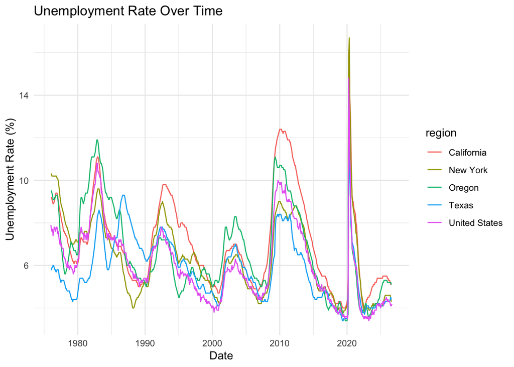

The graph above is showing the unemployment rate over time for the different states/the entire country on one graph.

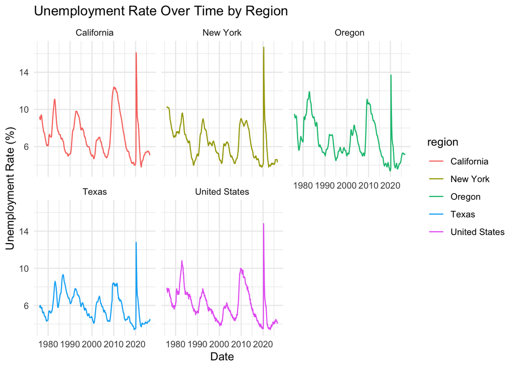

The graph above shows the employment rate over time for the different states/the entire country on separate graphs.

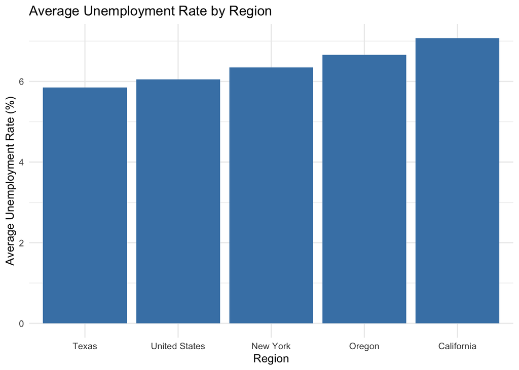

The graph above shows the average unemployment rate from 1976 to 2026 for the different states/the entire country.

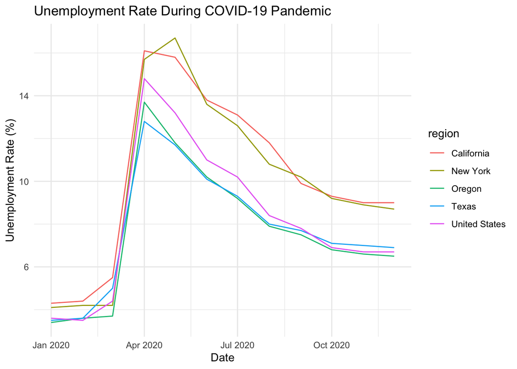

For this graph I used the unemp_covid data frame, which filters the unemployment data to only include the year 2020. This allows us to focus on the impact of the COVID-19 pandemic on unemployment rates across different regions. You can notice that New York pea after everyone else.

## Reflection

The coding was pretty straightforward for the most part, but formatting the quarto document is a bit tedious. I forgot about echo and was wondering why my code was showing. I feel pretty comfortable committing and pushing to github now. I need to work more with github to get fully comfortable with it.